### 2. Testing

The most basic plot would be a histogram of our rejection algorithm function with a large value of n applied to it:

```
## Empirical acceptance probability =  1e+06 / 1174179  =  0.8516589
```

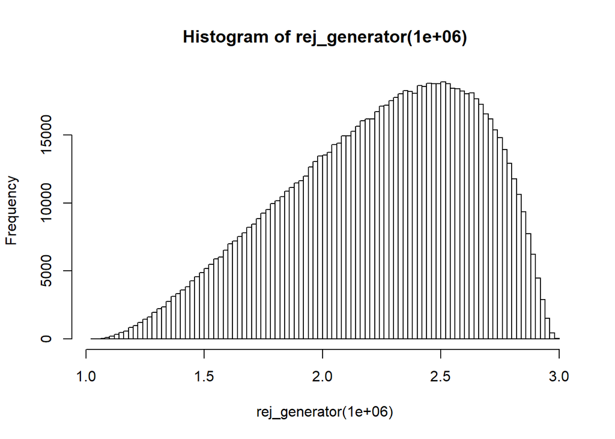

```r
hist(rej_generator(1000000),100)
```

Which thankfully mirrors the shape of our actual function $f*_X (x)$!

Another plot we could add is a lag plot, which would show that our generated numbers are uncorrelated:

```
## Empirical acceptance probability =  10000 / 11689  =  0.8555052
```

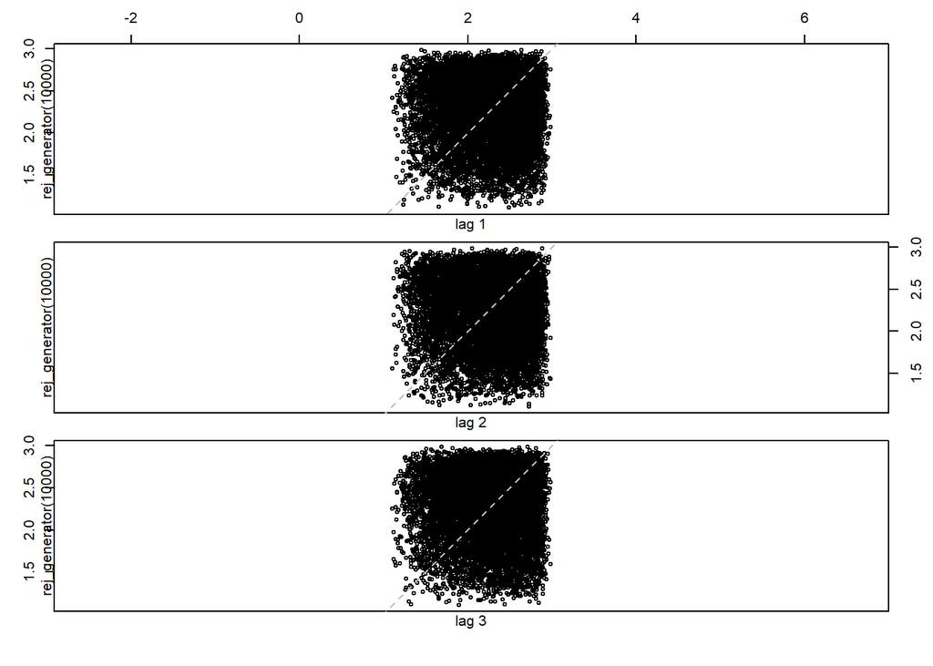

```r
lag.plot(rej_generator(10000),lags=3)
```

We see no trend, which is great!

We shall install nortest, a package containing various statistical/normality tests:

```r
#install nortest
library(nortest)
```

We will now rewrite our rejection function, but this time, we won’t print the acceptance probability each time we run it:

```r
rej_generator <- function(n){
#create empty nx1 vector of 0s
rand <- rep(0,n)
i <- 1
rejected <- 0
while(i<=n){
#generate random number from U(0,1)
u <- runif(1)
#sample from trapezium function
y <- trapezium(runif(1))
#accept if the below condition is satisfied
if( (M * g(y) * u) <= fstar(y)){
#replace ith element of vector rand with y
rand[i] <- y
i <- i+1
}
#reject otherwise, add 1 to the running total of rejected values
else rejected <- rejected+ 1
}
rand
}
```

The Lindeberg-Lévy version of the Central Limit Theorem states that the asymptotic distribution of the random variable $\sqrt{n}\frac{S_n-\mu}{\sigma}$ is $N\sim(0,1)$, where $S_n$ is our sample mean, given that our samples are independent and identically distributed, and $\mu$ is the true mean of our distribution.

We calculate the mean and variance of our pdf $f_X (x)$ as follows:

```r
xfstar<-function(x){
  #note f(x)=f*(x)/1.251334, our normalising constant
  xfstar<-x*fstar(x)/1.251334
  return(xfstar)
}
#integrate xf(x) to find the mean
integrate(xfstar,1,3)
```

```
## 2.247085 with absolute error < 5.3e-06
```

```r
#define x^2 f(x)
 xsquaredfstar<-function(x){
xsquaredfstar<-(x^2)*fstar(x)/1.251334
return(xsquaredfstar)
 }
#integral x f*(x)=2.247085
integrate(xsquaredfstar,1,3)
```

```
## 5.199436 with absolute error < 1.5e-05
```

```r
#integral x^2 f*(x)=5.199436
#use variance formula:
mean=2.247085
var=5.199436-(2.247085)^2
#compute standard deviation
sigma=sqrt(var)
```

```r
#form array of test statistics
test_stat_grid<-function(n){
  stat_vec=rep(0,n)
  i=1
  while(i<n){
    #generate 10000 random numbers and find mean
  sample_mean=sum(rej_generator(10000))/10000
  #use sqrt(n)*(sample mean-mean)
  stat_vec[i]<-sqrt(10000)*(sample_mean-mean)/sigma
  i=i+1
  }
  return(stat_vec)
}
```

A possible statistical test which checks whether our samples follow a standard normal distribution $N(0,1)$ is the Anderson-Darling test:

```r
ad.test(test_stat_grid(1000))
```

```
##
##  Anderson-Darling normality test
##
## data:  test_stat_grid(1000)
## A = 0.24678, p-value = 0.7546
```

Our p value is above 0.05, so we accept our null hypothesis, i.e. the central limit theorem is obeyed.

Another such normality test is the Cramer-von Mises test:

```r
cvm.test(test_stat_grid(1000))
```

```
##
##  Cramer-von Mises normality test
##
## data:  test_stat_grid(1000)
## W = 0.018825, p-value = 0.9775
```

Again, our p value is above 0.05, which leads us to accept our null hypothesis again.

### 3. Monte Carlo

A Monte Carlo method can be used to estimate our normalising constant $\frac{1}{\theta}$ where $\theta=\int f*_X (x) \mathrm{d}x=\int \phi(x)f(x) \mathrm{d}x=\mathrm{E}_f[\phi(X)]$, $f(x)$ being a pdf, such that $f_X (X)=\frac{f*_ X(x)}{\theta}$ is a valid probability density function.

In hit-or-miss Monte Carlo, we look for a constant $c$ such that $c=sup_{x} f*_X (x)$. Our $f(x)$ here is a rectangle function of the form $f(x)=\frac{1}{2}=\frac{1}{b-a}$, with $a=1,b=3$, and theta is therefore equal to $\int^3_1 f*_X (x)f(x)\mathrm{d}x$.

```r
c=max(fstar(x))
```

Our algorithm can be defined as follows:

1. Set i=1
2. Let I=rep(0,n)
3. While $i< n$: Generate $U=u_i \sim U(1,3)$ Generate $V=v_i \sim U(0,c)$ If $v_i \leq f*_X (u_i)$, let $I[i]=1$ i=i+1
4. $\tilde{\theta}=\frac{c(3-1)\Sigma I}{n}$

In our specific case, $\tilde{\theta}=2c\frac{\sum^n_{i=1}\mathbb{I}(v_i \leq f*_X (u_i))}{n}$, where $(3-1)c=2c$ is the area of our bounding rectangle and $\frac{\sum^n_{i=1}\mathbb{I}(v_i \leq f*_X (u_i))}{n}$ is the proportion of our points lying below our function $f*_X$.

```r
hitmiss_mc<-function(n){
  i<-1
  #create empty 1xn vec of 0s
  I=rep(0,n)
  while(i<n){
    #generate random uniform between 1 and 3
    u=runif(1,1,3)
    #generate random uniform between 0 and c
    v=runif(1,0,c)
    #
    if(v<=fstar(u)) {
      #if condition satisifed, ith element of I becomes 1
      I[i]<-1
    }
    i=i+1
  }
#calculate estimator
theta_est<-2*c*sum(I)/n
return(theta_est)
}
```

Another Monte Carlo method is Monte Carlo with importance sampling (instead of direct sampling):

$\theta=\int \phi(x)f(x)\mathrm{d}x=\int\phi(x)\frac{f(x)}{g(x)}g(x)\mathrm{d}x=\int\phi(x)W(x)g(x)\mathrm{d}x=\mathrm{E}_g [W(x)\phi(x)]$ with the condition that $f(x)>0 \implies g(x)>0$. If we let $\phi(x)=k$, which is 1 divided by our normalising constant, it is easy to show that an unbiased estimator of $\theta$ is $\hat{\theta}_{IS}=\frac{1}{n}\sum^n_{i=1} W(X_i)\phi(X_i)$, which becomes simply $\frac{1}{n}\sum^n_{i=1} \frac{f*_X (X_i)}{g(X_i)}$.

A safe choice of $g(x)$ is the trapezium function we used for our rejection algorithm, as we know that we can sample from that function using inversion:

```r
importance_mc<-function(n){
  i<-1
  #create empty vec of 0s
  MC<-rep(0,n)
  while(i<n){
    #sampling x from trapezium function
    x<-trapezium(runif(1))
    #ith element of vector becomes f*/g
    MC[i]<-fstar(x)/g(x)
    i<-i+1
  }
  #calculate estimator
  theta_est<-sum(MC)/n
  return(theta_est)
}
```

Now it’s time to compare the mean and variance of 1000 realisations of our two estimators:

```r
realization_importance_mc<-function(n){
importance_vec<-rep(0,n)
i<-1
while(i<n){
importance_vec[i]<-importance_mc(10000)
i<-i+1
}
return(importance_vec)
}
mean(realization_importance_mc(1000))
```

```
## [1] 1.251929
```

```r
var(realization_importance_mc(1000))
```

```
## [1] 0.001575965
```

```r
realization_hitmiss_mc<-function(n){
hitmiss_vec<-rep(0,n)
i<-1
while(i<n){
hitmiss_vec[i]<-hitmiss_mc(10000)
i<-i+1
}
return(hitmiss_vec)
}
mean(realization_hitmiss_mc(1000))
```

```
## [1] 1.251709
```

```r
var(realization_hitmiss_mc(1000))
```

```
## [1] 0.001709334
```